# Literacy and Unemployemnt GGPLOT Tutorial

## Join of Tables for Analysis

By using an inner join we are able to merge the Happiness and Cleaned_Literacy tables by the shared varaible(column) of “Country,” and remove all of the countries where there are no matches for “Country,” so that we only have countries with values rather than NULL in our final analysis.

```r
Happiness_Literacy <-
  Happiness %>%
  inner_join(Cleaned_Literacy)
Happiness_Literacy
```

| rank | Country | Score | gdp | support | lifeExpectancy | freedom | Generosity | corruption | Y2018 |
| --- | --- | --- | --- | --- | --- | --- | --- | --- | --- |
| 13 | Costa Rica | 7.072 | 1.010 | 1.459 | 0.817 | 0.632 | 0.143 | 0.101 | 97.86379 |
| 22 | Malta | 6.627 | 1.270 | 1.525 | 0.884 | 0.645 | 0.376 | 0.142 | 94.50319 |
| 24 | Mexico | 6.488 | 1.038 | 1.252 | 0.761 | 0.479 | 0.069 | 0.095 | 95.37991 |
| 27 | Panama | 6.430 | 1.112 | 1.438 | 0.759 | 0.597 | 0.125 | 0.063 | 95.41181 |
| 28 | Brazil | 6.419 | 0.986 | 1.474 | 0.675 | 0.493 | 0.110 | 0.088 | 93.22750 |
| 29 | Argentina | 6.388 | 1.073 | 1.468 | 0.744 | 0.570 | 0.062 | 0.054 | 99.00387 |
| 31 | Uruguay | 6.379 | 1.093 | 1.459 | 0.771 | 0.625 | 0.130 | 0.155 | 98.70386 |
| 34 | Singapore | 6.343 | 1.529 | 1.451 | 1.008 | 0.631 | 0.261 | 0.457 | 97.34486 |
| 35 | Malaysia | 6.322 | 1.161 | 1.258 | 0.669 | 0.356 | 0.311 | 0.059 | 94.85441 |
| 36 | Spain | 6.310 | 1.251 | 1.538 | 0.965 | 0.449 | 0.142 | 0.074 | 98.43650 |

[output cut: 49 more lines]

```r
NA
```

### Plot of the Relationship between Happiness and Literacy

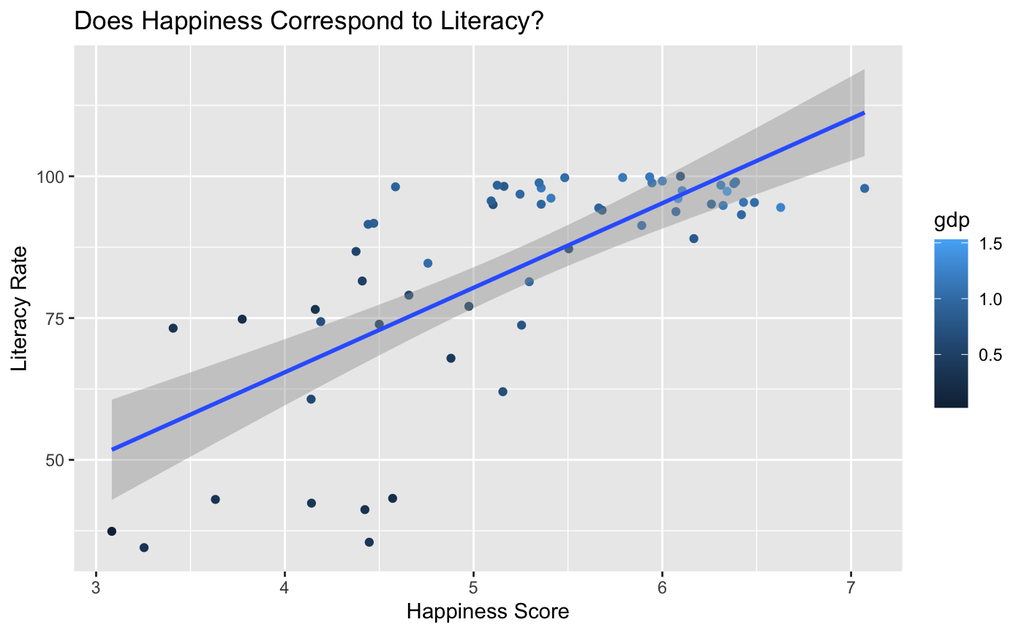

```r
Happiness_Literacy %>%
  ggplot(aes(x = Score, y = Y2018 ))+
  geom_point(aes(color = gdp))+
  stat_smooth(method = lm)+
  labs(x = "Happiness Score", y = "Literacy Rate", title = "Does Happiness Correspond to Literacy?")
```

### Application of Ggplot

The Ggplot library is an extremely versatile tool that can help point to the individual data points as well as the overarching trends of the data. For example, in our research project, ggplot helps us develop a linear line of best fit on our data set in order to see the location of each point, as well as, establishing a slope to understand the overall correlation of the data points. Within this line of best fit, there is a shaded region surrounding the line that shows us the confidence interval of the data, which was used to be able to show that there was a statisitcally significant relationship. This functionality allows for us to properly understand and formulate discussions and conclusions on the dataset. Without this graphical tool, I would not have been able to understand the correlation that exists between happiness indices and literacy rates of countries because the data points alone are not intuitive to a trend analysis.

The ggplot library allowed the input of several features such as axes labels, titles, color schemes, and scales, which was a great way for me to separate the data by the GDP of a country simply by adding a color separation feature to the graph. If your study is similar to this data set in that there are multiple variables that can influence the variables of study, this feature will allow you to account for them and see their impact on the data as well. Futhermore, depending on the type of data points you have collected, different types of graphs will be able to better suited to output the most optimal vizulizations. For example, this data is has two continuous variables for Happiness score and Literacy rate, which is why this linear model and line of best fix was best for our data. If the data is caegorical or ordinal, box plots and bar graphs may be more helpful.

The reason ggplot is so important is because data visualization is key in understanding trends of the dataset. Ggplot allows the researcher to highlight the important features of their findings and produce it in a way that is easily understood by most individuals. Having proper representation of the data allows for other researchers to properly replicate and compare your study with their own and use it for other purposes.